# IODS course project

## Standardisation and dividing dataset for both training and testing

```
##       crim                 zn               indus              chas
##  Min.   :-0.419367   Min.   :-0.48724   Min.   :-1.5563   Min.   :-0.2723
##  1st Qu.:-0.410563   1st Qu.:-0.48724   1st Qu.:-0.8668   1st Qu.:-0.2723
##  Median :-0.390280   Median :-0.48724   Median :-0.2109   Median :-0.2723
##  Mean   : 0.000000   Mean   : 0.00000   Mean   : 0.0000   Mean   : 0.0000
##  3rd Qu.: 0.007389   3rd Qu.: 0.04872   3rd Qu.: 1.0150   3rd Qu.:-0.2723
##  Max.   : 9.924110   Max.   : 3.80047   Max.   : 2.4202   Max.   : 3.6648
##       nox                rm               age               dis
##  Min.   :-1.4644   Min.   :-3.8764   Min.   :-2.3331   Min.   :-1.2658
##  1st Qu.:-0.9121   1st Qu.:-0.5681   1st Qu.:-0.8366   1st Qu.:-0.8049
##  Median :-0.1441   Median :-0.1084   Median : 0.3171   Median :-0.2790
##  Mean   : 0.0000   Mean   : 0.0000   Mean   : 0.0000   Mean   : 0.0000
##  3rd Qu.: 0.5981   3rd Qu.: 0.4823   3rd Qu.: 0.9059   3rd Qu.: 0.6617
##  Max.   : 2.7296   Max.   : 3.5515   Max.   : 1.1164   Max.   : 3.9566
##       rad               tax             ptratio            black
##  Min.   :-0.9819   Min.   :-1.3127   Min.   :-2.7047   Min.   :-3.9033
##  1st Qu.:-0.6373   1st Qu.:-0.7668   1st Qu.:-0.4876   1st Qu.: 0.2049
##  Median :-0.5225   Median :-0.4642   Median : 0.2746   Median : 0.3808
##  Mean   : 0.0000   Mean   : 0.0000   Mean   : 0.0000   Mean   : 0.0000
##  3rd Qu.: 1.6596   3rd Qu.: 1.5294   3rd Qu.: 0.8058   3rd Qu.: 0.4332
##  Max.   : 1.6596   Max.   : 1.7964   Max.   : 1.6372   Max.   : 0.4406
##      lstat              medv
##  Min.   :-1.5296   Min.   :-1.9063
##  1st Qu.:-0.7986   1st Qu.:-0.5989
##  Median :-0.1811   Median :-0.1449
##  Mean   : 0.0000   Mean   : 0.0000
##  3rd Qu.: 0.6024   3rd Qu.: 0.2683
##  Max.   : 3.5453   Max.   : 2.9865
```

From the summary of the data after scaling, we can observe that the all their mean has been change to zero. This is because the formula of scale takes the difference between each data point and mean. THe values are smaller as they are divded by their standard deviation i.e 1 = 1 standard deviation away from the mean. The values now provide insights on the distribution of the data.

```
## crime
##      low  med_low med_high     high
##      127      126      126      127
```

We can observe that there is equal spread of crime in all the 4 quartiles.

## Fitting with linear discriminant analysis

### Drawing the biplot

```
## Call:
## lda(crime ~ ., data = train)
##
## Prior probabilities of groups:
##       low   med_low  med_high      high
## 0.2475248 0.2400990 0.2500000 0.2623762
##
## Group means:
##                  zn      indus        chas        nox          rm        age
## low       1.0031691 -0.9484904 -0.07547406 -0.8959194  0.43816980 -0.9024841
## med_low  -0.1139439 -0.3007983 -0.02879709 -0.5733491 -0.10653153 -0.2926508
## med_high -0.3921463  0.1974978  0.31238879  0.3693549  0.06111418  0.3702504
## high     -0.4872402  1.0170298 -0.12375925  1.0251803 -0.47765143  0.8138539
##                 dis        rad        tax     ptratio      black       lstat
## low       0.9342247 -0.6981998 -0.7259953 -0.45753280  0.3766517 -0.77888466
## med_low   0.3511349 -0.5532680 -0.5481373 -0.02517508  0.3267987 -0.12124903
## med_high -0.3557790 -0.3826216 -0.2885020 -0.25248797  0.1161488  0.04152614
## high     -0.8614255  1.6390172  1.5146914  0.78181164 -0.6811918  0.91133232
##                 medv
## low       0.50844197
## med_low   0.01257432
## med_high  0.12766240
## high     -0.71082411
##
## Coefficients of linear discriminants:
##                 LD1         LD2         LD3
## zn       0.08931015  0.82998652 -0.79679062
## indus    0.03645657 -0.37211139  0.39767198
## chas    -0.09080861 -0.10255736 -0.04638273
## nox      0.32917694 -0.52021251 -1.46928331
## rm      -0.10453320 -0.06527335 -0.13391341
## age      0.28886536 -0.26912705 -0.01896865
## dis     -0.08631530 -0.28901759  0.17391209
## rad      2.91227697  0.93446287  0.38165731
## tax      0.09099372 -0.04505454 -0.01818248
## ptratio  0.09008668  0.03166109 -0.16066391
## black   -0.15189422  0.01295430  0.11830801
## lstat    0.23262161 -0.24754000  0.38256183
## medv     0.19562834 -0.34202401 -0.16918731
##
## Proportion of trace:
##    LD1    LD2    LD3
## 0.9470 0.0409 0.0121
```

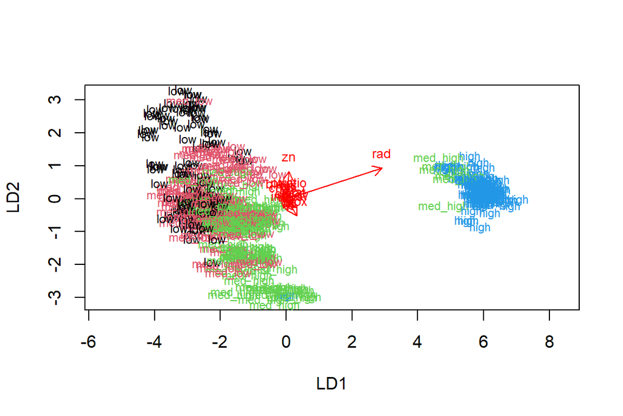

LDA provides the coefficient of a linear combination of variables. From the plot, we can observe that accessibility to radial highways (rad) has the highest LD1 coefficient, which suggests that it tends towards the med_high, high region. The coefficents of LD2 are all below 1.

### Predicting the test data

```
##           predicted
## correct    low med_low med_high high
##   low       13      13        1    0
##   med_low    7      14        8    0
##   med_high   0       7       18    0
##   high       0       0        0   21
```

The table shows the predicted results based on the number of correct entries. The correctness of the testing power can be vaguely determined by the highest number of entries in the correct percentile. i.e highest number should be in low for the low row and etc.